# Practical 1 Fitting and Evaluating models

2022-04-13

If you haven’t installed the libraries “dplyr”, “glmnet”, “mlbench” and “ranger” yet, run this code.

```r
list.of.packages <- c("dplyr", "glmnet", "mlbench", "ranger", "pROC", "ISLR")
new.packages <- list.of.packages[!(list.of.packages %in% installed.packages()[,"Package"])]
if(length(new.packages)) install.packages(new.packages)
```

load the libraries

```r
library(glmnet)
library(dplyr)
library(mlbench)
library(ranger)
library(pROC)
```

## 1.1 Hitters

In this exercise you will learn how to train and evaluate linear models with the “glmnet” library. It contains the Elastic Net algorithm, which is a combination of Ridge and Lasso regression.

The data we use here are statistical records of American baseball players in 1986 and 1987. More information about this data can be found in https://www.kaggle.com/datasets/floser/hitters?msclkid=a7936d81bc9211ec9522d9a294f2c801.

Your task is to predict the players’ salaries from the other features (variables) in the dataset. The average salary in the ’80s was pretty high already, around $500k a year. Nowadays, in 2022, this is around $5 million. After this machine learning course, perhaps you should consider a course catching and throwing balls as well. But first things first, good luck with this machine learning practical!

#### Load data

You can first set a seed in order to get reproducible results. Then load the data with the line below. The dataframe `Hitters` is automatically generated. The first few samples of `Hitters` are obtained with `head(Hitters)`

```r
set.seed(123)
data(Hitters, package = "ISLR")
head(Hitters)
```

```
##                   AtBat Hits HmRun Runs RBI Walks Years CAtBat CHits CHmRun
## -Andy Allanson      293   66     1   30  29    14     1    293    66      1
## -Alan Ashby         315   81     7   24  38    39    14   3449   835     69
## -Alvin Davis        479  130    18   66  72    76     3   1624   457     63
## -Andre Dawson       496  141    20   65  78    37    11   5628  1575    225
## -Andres Galarraga   321   87    10   39  42    30     2    396   101     12
## -Alfredo Griffin    594  169     4   74  51    35    11   4408  1133     19
##                   CRuns CRBI CWalks League Division PutOuts Assists Errors
## -Andy Allanson       30   29     14      A        E     446      33     20
## -Alan Ashby         321  414    375      N        W     632      43     10
## -Alvin Davis        224  266    263      A        W     880      82     14
## -Andre Dawson       828  838    354      N        E     200      11      3
## -Andres Galarraga    48   46     33      N        E     805      40      4
## -Alfredo Griffin    501  336    194      A        W     282     421     25
##                   Salary NewLeague
## -Andy Allanson        NA         A
## -Alan Ashby        475.0         N
## -Alvin Davis       480.0         A
## -Andre Dawson      500.0         N
## -Andres Galarraga   91.5         N
## -Alfredo Griffin   750.0         A
```

#### 1. Analyse data

Do some general data analysis.

**a. How large is this dataset actually?**

```r
dim(Hitters)
```

```
## [1] 322  20
```

**b. Is this a regression or classification task?**  
This is a regression task because the variable to predict (salary) is continuous.  
**c. What are the mean and median of the salaries? A histogram of the salaries could give you even better insights.**  
Using the function `summary` gives a lot of info at once. Mean salary is $535.9 k, median salary is $425.0 k

```r
summary(Hitters)
```

```
##      AtBat            Hits         HmRun            Runs
##  Min.   : 16.0   Min.   :  1   Min.   : 0.00   Min.   :  0.00
##  1st Qu.:255.2   1st Qu.: 64   1st Qu.: 4.00   1st Qu.: 30.25
##  Median :379.5   Median : 96   Median : 8.00   Median : 48.00
##  Mean   :380.9   Mean   :101   Mean   :10.77   Mean   : 50.91
##  3rd Qu.:512.0   3rd Qu.:137   3rd Qu.:16.00   3rd Qu.: 69.00
##  Max.   :687.0   Max.   :238   Max.   :40.00   Max.   :130.00
##
##       RBI             Walks            Years            CAtBat
##  Min.   :  0.00   Min.   :  0.00   Min.   : 1.000   Min.   :   19.0
##  1st Qu.: 28.00   1st Qu.: 22.00   1st Qu.: 4.000   1st Qu.:  816.8
##  Median : 44.00   Median : 35.00   Median : 6.000   Median : 1928.0
##  Mean   : 48.03   Mean   : 38.74   Mean   : 7.444   Mean   : 2648.7
##  3rd Qu.: 64.75   3rd Qu.: 53.00   3rd Qu.:11.000   3rd Qu.: 3924.2
##  Max.   :121.00   Max.   :105.00   Max.   :24.000   Max.   :14053.0
##
##      CHits            CHmRun           CRuns             CRBI
##  Min.   :   4.0   Min.   :  0.00   Min.   :   1.0   Min.   :   0.00
##  1st Qu.: 209.0   1st Qu.: 14.00   1st Qu.: 100.2   1st Qu.:  88.75
##  Median : 508.0   Median : 37.50   Median : 247.0   Median : 220.50
##  Mean   : 717.6   Mean   : 69.49   Mean   : 358.8   Mean   : 330.12
##  3rd Qu.:1059.2   3rd Qu.: 90.00   3rd Qu.: 526.2   3rd Qu.: 426.25
##  Max.   :4256.0   Max.   :548.00   Max.   :2165.0   Max.   :1659.00
##
##      CWalks        League  Division    PutOuts          Assists
##  Min.   :   0.00   A:175   E:157    Min.   :   0.0   Min.   :  0.0
##  1st Qu.:  67.25   N:147   W:165    1st Qu.: 109.2   1st Qu.:  7.0
##  Median : 170.50                    Median : 212.0   Median : 39.5
##  Mean   : 260.24                    Mean   : 288.9   Mean   :106.9
##  3rd Qu.: 339.25                    3rd Qu.: 325.0   3rd Qu.:166.0
##  Max.   :1566.00                    Max.   :1378.0   Max.   :492.0
##
##      Errors          Salary       NewLeague
##  Min.   : 0.00   Min.   :  67.5   A:176
##  1st Qu.: 3.00   1st Qu.: 190.0   N:146
##  Median : 6.00   Median : 425.0
##  Mean   : 8.04   Mean   : 535.9
##  3rd Qu.:11.00   3rd Qu.: 750.0
##  Max.   :32.00   Max.   :2460.0
##                  NA's   :59
```

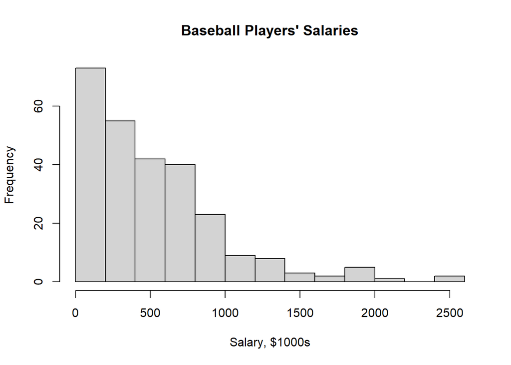

```r
hist(Hitters$Salary,
     xlab = "Salary, $1000s",
     main = "Baseball Players' Salaries")
```

**d. What data types does the data contain?**  
Using the `str()` function give you the types of data per column at once.

```r
str(Hitters)
```

```
## 'data.frame':    322 obs. of  20 variables:
##  $ AtBat    : int  293 315 479 496 321 594 185 298 323 401 ...
##  $ Hits     : int  66 81 130 141 87 169 37 73 81 92 ...
##  $ HmRun    : int  1 7 18 20 10 4 1 0 6 17 ...
##  $ Runs     : int  30 24 66 65 39 74 23 24 26 49 ...
##  $ RBI      : int  29 38 72 78 42 51 8 24 32 66 ...
##  $ Walks    : int  14 39 76 37 30 35 21 7 8 65 ...
##  $ Years    : int  1 14 3 11 2 11 2 3 2 13 ...
##  $ CAtBat   : int  293 3449 1624 5628 396 4408 214 509 341 5206 ...
##  $ CHits    : int  66 835 457 1575 101 1133 42 108 86 1332 ...
##  $ CHmRun   : int  1 69 63 225 12 19 1 0 6 253 ...
##  $ CRuns    : int  30 321 224 828 48 501 30 41 32 784 ...
##  $ CRBI     : int  29 414 266 838 46 336 9 37 34 890 ...
##  $ CWalks   : int  14 375 263 354 33 194 24 12 8 866 ...
##  $ League   : Factor w/ 2 levels "A","N": 1 2 1 2 2 1 2 1 2 1 ...
##  $ Division : Factor w/ 2 levels "E","W": 1 2 2 1 1 2 1 2 2 1 ...
##  $ PutOuts  : int  446 632 880 200 805 282 76 121 143 0 ...
##  $ Assists  : int  33 43 82 11 40 421 127 283 290 0 ...
##  $ Errors   : int  20 10 14 3 4 25 7 9 19 0 ...
##  $ Salary   : num  NA 475 480 500 91.5 750 70 100 75 1100 ...
##  $ NewLeague: Factor w/ 2 levels "A","N": 1 2 1 2 2 1 1 1 2 1 ...
```

**e. Are there NaN values in the data? What to do with those?**  
The `Salary` column has 59 NaN values. Easiest is to remove them from the data.

```r
colSums(is.na(Hitters))
```

```
##     AtBat      Hits     HmRun      Runs       RBI     Walks     Years    CAtBat
##         0         0         0         0         0         0         0         0
##     CHits    CHmRun     CRuns      CRBI    CWalks    League  Division   PutOuts
##         0         0         0         0         0         0         0         0
##   Assists    Errors    Salary NewLeague
##         0         0        59         0
```

#### 2. Preprocess data

**a. The NaN values you found in 1 are not useful for training a model. The easiest way to deal with them is removing. Remove the samples that contain any NaNs. How many samples are left now? Is that sufficient?**

```r
Hitters = na.omit(Hitters)
dim(Hitters)
```

```
## [1] 263  20
```

263 rows are left. It is not a lot, but enough to try out training a machine learning model.

**b. For training linear models with regularization it is important to use scaled data. Otherwise the regularization treats the features unequally. Scale the numeric data using the `scale()` function. Make sure you put all data together back in one dataframe.**

```r
columns_scale = names(select(Hitters, -c(League, NewLeague, Division)))
Hitters[, columns_scale] <- scale(Hitters[, columns_scale])
head(Hitters)
```

```
##                        AtBat       Hits      HmRun       Runs         RBI
## -Alan Ashby       -0.6017532 -0.5945419 -0.5275454 -1.2038163 -0.52106946
## -Alvin Davis       0.5115664  0.4913228  0.7285771  0.4406748  0.79254856
## -Andre Dawson      0.6269715  0.7350884  0.9569630  0.4015202  1.02436351
## -Andres Galarraga -0.5610220 -0.4615789 -0.1849665 -0.6164981 -0.36652617
## -Alfredo Griffin   1.2922478  1.3555825 -0.8701243  0.7539112 -0.01880375
## -Al Newman        -1.4842626 -1.5696041 -1.2127031 -1.2429709 -1.68014419
##                         Walks      Years     CAtBat      CHits       CHmRun
## -Alan Ashby       -0.09734151  1.3952334  0.3461306  0.1740416 -0.002914243
## -Alvin Davis       1.60631004 -0.8994853 -0.4520036 -0.4091121 -0.075909091
## -Andre Dawson     -0.18943079  0.7694010  1.2990809  1.3156652  1.894951816
## -Andres Galarraga -0.51174324 -1.1080961 -0.9890495 -0.9583256 -0.696365303
## -Alfredo Griffin  -0.28152006  0.7694010  0.7655337  0.6337765 -0.611204646
## -Al Newman        -0.92614497 -1.1080961 -1.0686443 -1.0493469 -0.830189192
##                        CRuns        CRBI      CWalks League Division
## -Alan Ashby       -0.1214393  0.25847281  0.43450593      N        W
## -Alvin Davis      -0.4143150 -0.19921055  0.01035326      A        W
## -Andre Dawson      1.4093644  1.56967378  0.35497730      N        E
## -Andres Galarraga -0.9457182 -0.87955068 -0.86067453      N        E
## -Alfredo Griffin   0.4220413  0.01726131 -0.25095507      A        W
## -Al Newman        -1.0000663 -0.99397151 -0.89475822      N        E
##                       PutOuts     Assists     Errors      Salary NewLeague
## -Alan Ashby        1.21917406 -0.52219572  0.2129461 -0.13505511         N
## -Alvin Davis       2.10509535 -0.25337958  0.8184036 -0.12397155         A
## -Andre Dawson     -0.32404367 -0.74276281 -0.8466046 -0.07963732         N
## -Andres Galarraga  1.83717561 -0.54287389 -0.6952402 -0.98516400         N
## -Alfredo Griffin  -0.03111808  2.08325298  2.4834118  0.47454057         A
## -Al Newman        -0.76700431  0.05679288 -0.2411471 -1.03282329         A
```

#### 3. Prepare data for training

The model in the `glmnet` package requires data input where the features and target values (labels) are fed into the training function as separate arguments. Make a data matrix `X` for the features and a data matrix `y` for the targets. Use the function `data.matrix()` to convert a data frame to a data matrix. You can use the function `select()` from the `dplyr` package to separate features and targets.

```r
X <- data.matrix(dplyr::select(Hitters, -Salary))
y <- data.matrix(dplyr::select(Hitters, Salary))
```

#### 4. Train and evaluate

You might have noticed the dataset is quite small. Picking a single validation dataset will give an unreliable result (why?). The best way to train your model is the use of cross validation. Use the function `cv.glmnet()` for cross validation. A nice feature of this function is that it automatically trains for many different values of lambda (regularization parameter). You can specify the other parameter `alpha` (proportion ridge / lasso) yourself.

1. Train an Elastic Net model with 5-fold cross validation, plot the output. Let’s first try this with `alpha=0.5`. You can use the mean squared error (mse) as metric. Which value of lambda gives the best result?

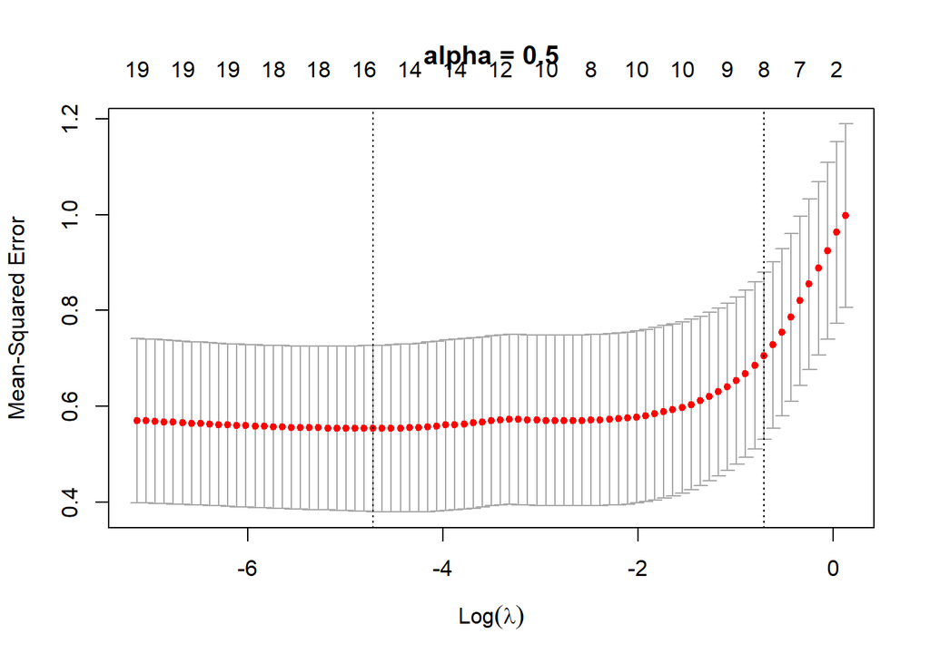

```r
set.seed(123)
fit_cv = cv.glmnet(X, y, alpha = 0.5, nfold=5,  type.measure = "mse")
plot(fit_cv, main=paste("alpha =", toString(0.5)))
```

```r
min_mse <- fit_cv$cvm[fit_cv$lambda == fit_cv$lambda.min] # best lambda, CV-MSE minimum
print(fit_cv$lambda.min)
```

```
## [1] 0.008969112
```

```r
print(min_mse)
```

```
## [1] 0.5537997
```

2. Make a cross validation “for loop” for different values of alpha (between 0 and 1). Use the mse as metric again. Which parameters give you the best model?

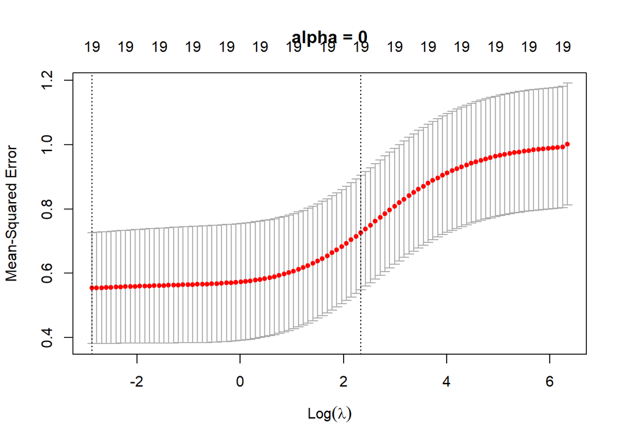

```
## [1] "alpha= 0 lambda_min= 0.056588677753129 MSE= 0.553789383784743"
```

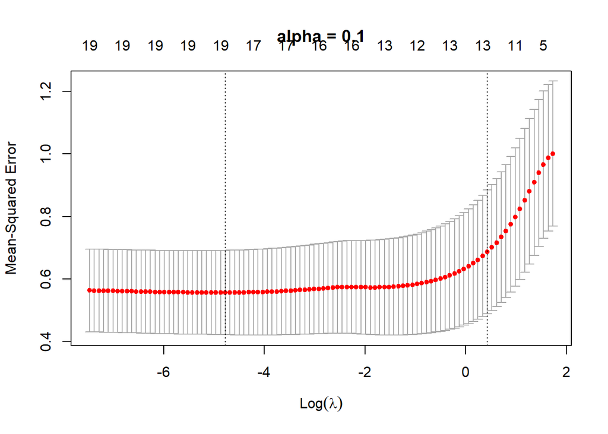

```
## [1] "alpha= 0.1 lambda_min= 0.00840323904663418 MSE= 0.556897028102677"
```

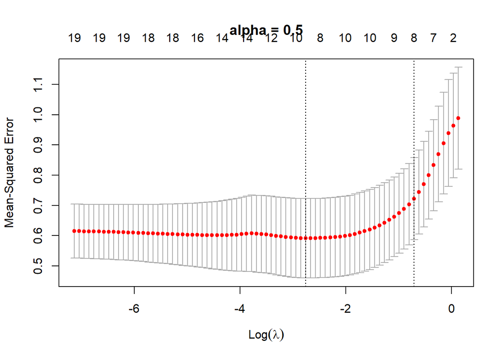

```
## [1] "alpha= 0.5 lambda_min= 0.0632753111594192 MSE= 0.591646366188179"
```

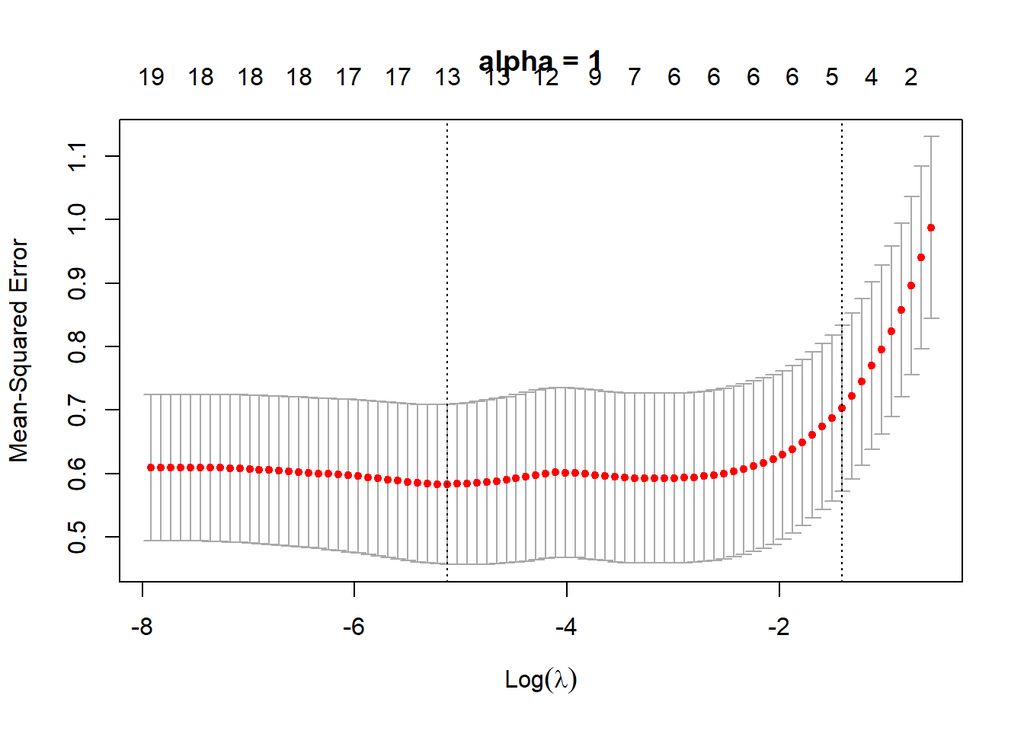

```
## [1] "alpha= 1 lambda_min= 0.0059283190243716 MSE= 0.583214727736484"
```

```r
set.seed(123)
for(alpha_cv in c(0, 0.1, 0.5, 1)){
  fit_cv <- cv.glmnet(X, y, nfold=5,  type.measure = "mse", alpha=alpha_cv)

  plot(fit_cv, main=paste("alpha =", toString(alpha_cv)))
  min_MSE <- fit_cv$cvm[fit_cv$lambda == fit_cv$lambda.min]

  print(paste("alpha=", alpha_cv, "lambda_min=", fit_cv$lambda.min, "MSE=", min_MSE)) # print MSE

}
```

For seed 123, alpha=0 and lambda=0.056589 gives the lowest mse and thus the best fit. However, note that the mse values vary with varying seed, which means there is some statistical fluctuation dependent on train-validation sample selection and automatic lambda selection by the software.

#### 5. Improve model performance

In order to improve prediction performance, let’s check what happens if we add the cross terms as features. An example of a cross term is “Hits” x “Runs”. A quick way to obtain data including all possible cross terms is `X = model.matrix(Salary ~ . ^ 2, Hitters)[,-1]`

**a. Make a new feature set with all cross terms and perform cross validation again. Can you improve the prediction performance?**

```r
X = model.matrix(Salary ~ . ^ 2, Hitters)[,-1]
y = Hitters$Salary
```

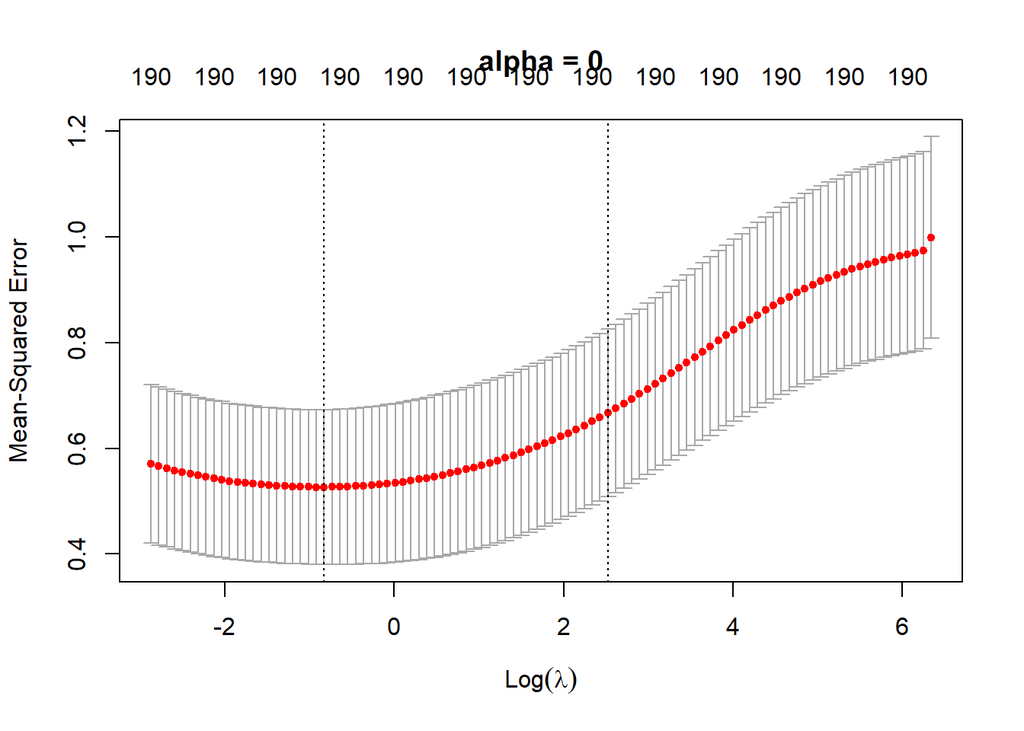

```
## [1] "alpha = 0 lambda_min = 0.438145580351932 MSE = 0.52649394138667"
```

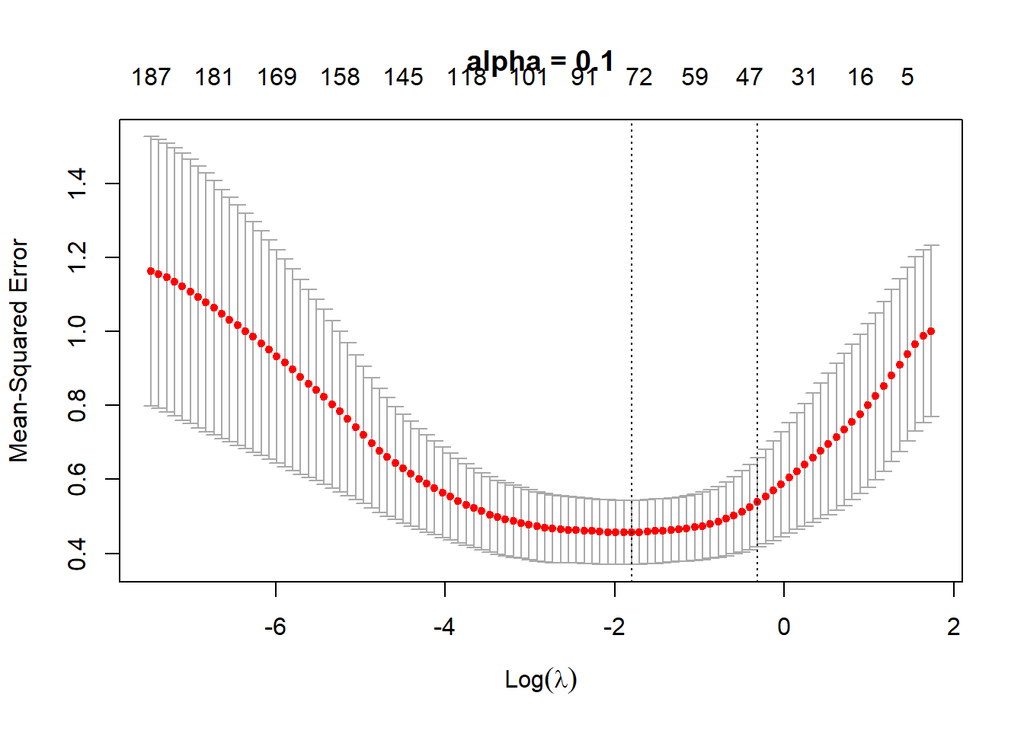

```
## [1] "alpha = 0.1 lambda_min = 0.164958998405485 MSE = 0.456614867049332"
```

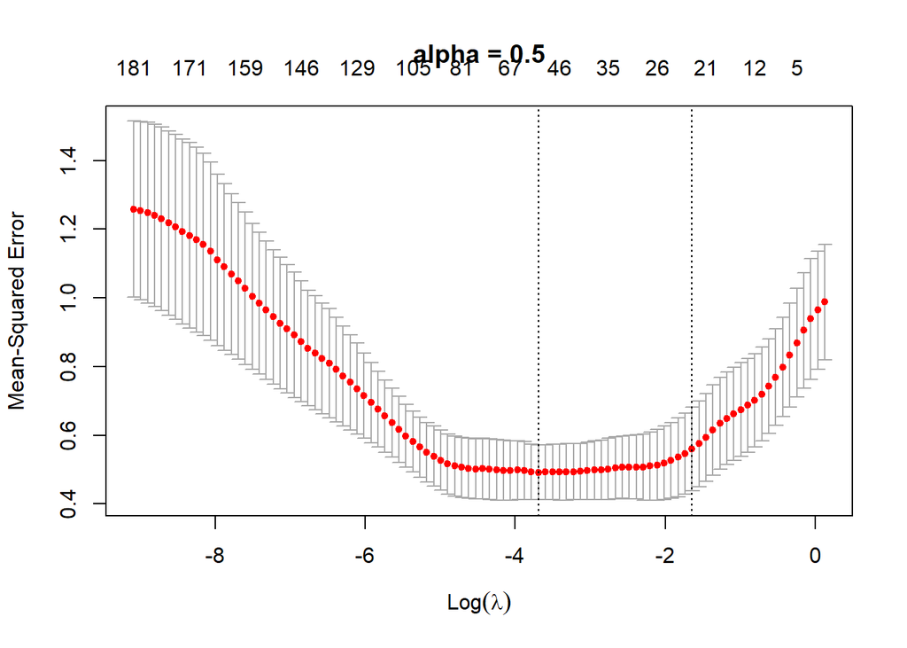

```
## [1] "alpha = 0.5 lambda_min = 0.0249570865687785 MSE = 0.491651763274229"
```

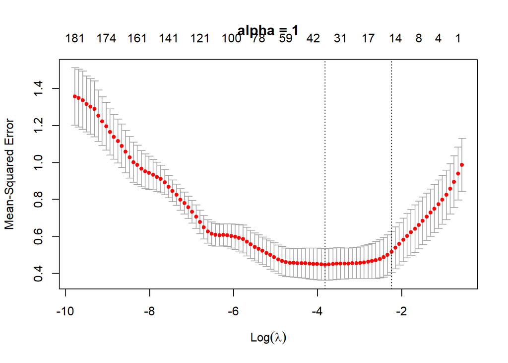

```
## [1] "alpha = 1 lambda_min = 0.0218066087801953 MSE = 0.447171392441645"
```

```r
set.seed(123)
for(alpha_cv in c(0, 0.1, 0.5, 1)){
  fit_cv <- cv.glmnet(X, y, nfold=5,  type.measure = "mse", alpha=alpha_cv)

  plot(fit_cv, main=paste("alpha =", toString(alpha_cv)))
  min_MSE <- fit_cv$cvm[fit_cv$lambda == fit_cv$lambda.min]

  print(paste("alpha =", alpha_cv, "lambda_min =", fit_cv$lambda.min, "MSE =", min_MSE)) # print MSE
}
```

Yes, the mse’s are lower now. High values of alpha give the best results. Note that the mse values vary with varying seed, which means there is some statistical fluctuation dependent on train-validation sample selection.

**b. What happens with the model coefficients for increased alpha? (use function `coef()` to obtain them). Can you explain this? If your code is correct you will see that alpha works as a feature selection parameter in the Lasso algorithm.**

```r
set.seed(123)
for(alpha_cv in c(0, 0.1, 0.5, 1)){
  fit_cv <- cv.glmnet(X, y, nfold=5,  type.measure = "mse", alpha=alpha_cv)
  min_MSE <- fit_cv$cvm[fit_cv$lambda == fit_cv$lambda.min]

  print(paste('alpha =', alpha_cv))
  print(coef(fit_cv, s=fit_cv$lambda.min))
}
```

```
## [1] "alpha = 0"
## 191 x 1 sparse Matrix of class "dgCMatrix"
##                                 s1
## (Intercept)           0.0138476685
## AtBat                 0.0447218118
## Hits                  0.0826897892
## HmRun                 0.0206621287
## Runs                  0.0521740178
## RBI                   0.0386291697
## Walks                 0.0682806788
## Years                 0.0091707832
## CAtBat                0.0795180991
## CHits                 0.1004853284
## CHmRun                0.1135457330
## CRuns                 0.1098146521
## CRBI                  0.1104693022
## CWalks                0.0784074803
## LeagueN               0.0438921474
## DivisionW            -0.0884493094
## PutOuts               0.0452725726
## Assists               0.0130836894
## Errors                0.0004782910
## NewLeagueN            0.0654729845
## AtBat:Hits            0.0408492213
## AtBat:HmRun          -0.0133126243
## AtBat:Runs            0.0119232697
## AtBat:RBI            -0.0070345905
## AtBat:Walks           0.0382746621
## AtBat:Years           0.0445469235
## AtBat:CAtBat          0.0077134321
## AtBat:CHits           0.0019594557
## AtBat:CHmRun          0.0028047428
## AtBat:CRuns           0.0042400446
## AtBat:CRBI            0.0028373784
## AtBat:CWalks         -0.0044277867
## AtBat:LeagueN        -0.0463477047
## AtBat:DivisionW       0.0081816497
## AtBat:PutOuts        -0.0178475864
## AtBat:Assists        -0.0358076011
## AtBat:Errors         -0.0123516736
```

[output cut: 721 more lines]

```
## LeagueN:DivisionW     .
## LeagueN:PutOuts       0.0858468073
## LeagueN:Assists       .
## LeagueN:Errors        .
## LeagueN:NewLeagueN    .
## DivisionW:PutOuts     .
## DivisionW:Assists    -0.0115166101
## DivisionW:Errors      .
## DivisionW:NewLeagueN  .
## PutOuts:Assists      -0.2800391767
## PutOuts:Errors        .
## PutOuts:NewLeagueN    .
## Assists:Errors        .
## Assists:NewLeagueN    .
## Errors:NewLeagueN     .
```

The closer alpha to 1, the more feature coefficients are set to zero. This is the result of the feature selection mechanism of the Lasso algorithm. This enables us to get insight on which features are useful for predictions and which are not.

## 1.2 Diabetes prediction

Welcome to the second exercise. Here you will predict whether a member in the Pima Indian dataset has diabetes or not. First load the data. The loaded data frame is `PimaIndiansDiabetes`. The first rows are obtained with `head(PimaIndiansDiabetes)`

```r
data(PimaIndiansDiabetes)
head(PimaIndiansDiabetes)
```

```
##   pregnant glucose pressure triceps insulin mass pedigree age diabetes
## 1        6     148       72      35       0 33.6    0.627  50      pos
## 2        1      85       66      29       0 26.6    0.351  31      neg
## 3        8     183       64       0       0 23.3    0.672  32      pos
## 4        1      89       66      23      94 28.1    0.167  21      neg
## 5        0     137       40      35     168 43.1    2.288  33      pos
## 6        5     116       74       0       0 25.6    0.201  30      neg
```

### 1. Explore the data

Make a summary of the data and check the data types. How many positive and negative diabetes samples do the data contain?

```r
summary(PimaIndiansDiabetes)
```

```
##     pregnant         glucose         pressure         triceps
##  Min.   : 0.000   Min.   :  0.0   Min.   :  0.00   Min.   : 0.00
##  1st Qu.: 1.000   1st Qu.: 99.0   1st Qu.: 62.00   1st Qu.: 0.00
##  Median : 3.000   Median :117.0   Median : 72.00   Median :23.00
##  Mean   : 3.845   Mean   :120.9   Mean   : 69.11   Mean   :20.54
##  3rd Qu.: 6.000   3rd Qu.:140.2   3rd Qu.: 80.00   3rd Qu.:32.00
##  Max.   :17.000   Max.   :199.0   Max.   :122.00   Max.   :99.00
##     insulin           mass          pedigree           age        diabetes
##  Min.   :  0.0   Min.   : 0.00   Min.   :0.0780   Min.   :21.00   neg:500
##  1st Qu.:  0.0   1st Qu.:27.30   1st Qu.:0.2437   1st Qu.:24.00   pos:268
##  Median : 30.5   Median :32.00   Median :0.3725   Median :29.00
##  Mean   : 79.8   Mean   :31.99   Mean   :0.4719   Mean   :33.24
##  3rd Qu.:127.2   3rd Qu.:36.60   3rd Qu.:0.6262   3rd Qu.:41.00
##  Max.   :846.0   Max.   :67.10   Max.   :2.4200   Max.   :81.00
```

```r
str(PimaIndiansDiabetes)
```

```
## 'data.frame':    768 obs. of  9 variables:
##  $ pregnant: num  6 1 8 1 0 5 3 10 2 8 ...
##  $ glucose : num  148 85 183 89 137 116 78 115 197 125 ...
##  $ pressure: num  72 66 64 66 40 74 50 0 70 96 ...
##  $ triceps : num  35 29 0 23 35 0 32 0 45 0 ...
##  $ insulin : num  0 0 0 94 168 0 88 0 543 0 ...
##  $ mass    : num  33.6 26.6 23.3 28.1 43.1 25.6 31 35.3 30.5 0 ...
##  $ pedigree: num  0.627 0.351 0.672 0.167 2.288 ...
##  $ age     : num  50 31 32 21 33 30 26 29 53 54 ...
##  $ diabetes: Factor w/ 2 levels "neg","pos": 2 1 2 1 2 1 2 1 2 2 ...
```

### 2. Prepare data for training

For simplicity we don’t do cross validation here, but we just make a separate validation training dataset. Split the data into 80% train and 20% validation data.

```r
train.idx <- sample(nrow(PimaIndiansDiabetes), 0.8 * nrow(PimaIndiansDiabetes))
data_train<- PimaIndiansDiabetes[train.idx, ]
data_val <- PimaIndiansDiabetes[-train.idx, ]
```

### 3. Training

Use the `ranger` function to train a random forest model on the training data.

```r
set.seed(123)
fit_rf <- ranger(diabetes  ~ ., data = data_train, probability = TRUE)
print(fit_rf)
```

```
## Ranger result
##
## Call:
##  ranger(diabetes ~ ., data = data_train, probability = TRUE)
##
## Type:                             Probability estimation
## Number of trees:                  500
## Sample size:                      614
## Number of independent variables:  8
## Mtry:                             2
## Target node size:                 10
## Variable importance mode:         none
## Splitrule:                        gini
## OOB prediction error (Brier s.):  0.1538063
```

### 4. Evaluate

Make predictions on the validation data with the function `predict()`. From the predictions and true diabetes values, make a confusion matrix and calculate the accuracy.

```r
preds <- predict(fit_rf, data = data_val)
cm <- table(data_val$diabetes, preds$predictions[,2] > 0.5)
accuracy <- sum(cm[1], cm[4]) / sum(cm[1:4])
print(cm)
```

```
##
##       FALSE TRUE
##   neg    82   17
##   pos    23   32
```

```r
print(accuracy)
```

```
## [1] 0.7402597
```

### 5. AUC

Use the function `roc` and `auc` from the pROC library to plot ROC-curve and to calculate the AUC. Make sure the “positive” cases agree with “pos” and the control cases agree with “neg”. If you swap those, you will get another results (why?).

```r
roc_pima <- pROC::roc(data_val$diabetes, preds$predictions[,2])
```

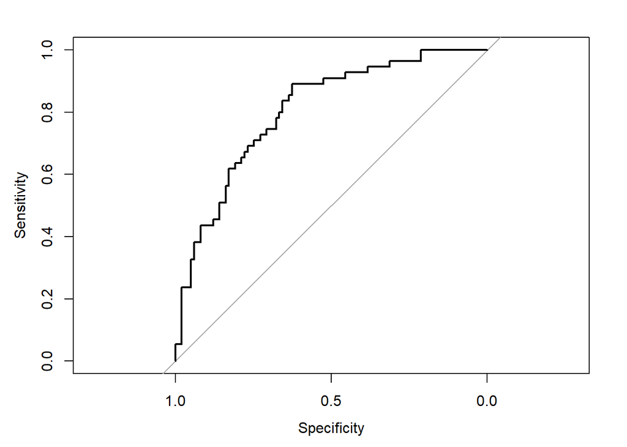

```r
plot(roc_pima)
```

```r
auc_pima <- pROC::auc(data_val$diabetes, preds$predictions[,2])
print(auc_pima)
```

```
## Area under the curve: 0.804
```

The auc is based on true positives, true negatives, false positives and false negatives. Those values change if you change “neg” to the ‘positive’ case and “pos” to the ‘negative’ case.

### 6. Improve performance

The default number of trees used in the ranger library is 500. Vary the number of trees and check how much you can improve the model. Use the argument `num.trees`. What do you notice? In order to get reproducible results, set the seed `set.seed(123)` each time you run.

```r
set.seed(123)
for(ntrees in c(10, 50, 100, 500, 1000)){
  fit_rf <- ranger(diabetes  ~ ., data = data_train, num.trees=ntrees)
  preds <- predict(fit_rf, data = data_val)
  cm <- table(data_val$diabetes, preds$predictions)
  accuracy <- sum(cm[1], cm[4]) / sum(cm[1:4])
  auc_pima <- pROC::auc(as.numeric(preds$predictions), as.numeric(data_val$diabetes))
  print(paste("ntrees =", ntrees, "accuracy = ", accuracy, "auc = ", auc_pima))
}
```

```
## [1] "ntrees = 10 accuracy =  0.701298701298701 auc =  0.67364094900056"
## [1] "ntrees = 50 accuracy =  0.746753246753247 auc =  0.724230769230769"
## [1] "ntrees = 100 accuracy =  0.727272727272727 auc =  0.702075004759185"
## [1] "ntrees = 500 accuracy =  0.733766233766234 auc =  0.709709119496855"
## [1] "ntrees = 1000 accuracy =  0.746753246753247 auc =  0.724230769230769"
```

More trees give better performance in general, but there is always a plateau where the performance flattens off. In this small data set example, it seems that this plateau is already reached around 50 trees. However, this can change if you change the seed! (try it yourself!). So, there is a large random factor involved.